# Advanced Modelling

Maxi Kellerbauer

2019-01-03

# Read the data

We load the daily data of Munich for PM2.5

```r
data("muc_airPol_p2")
```

remove outliers in the data

```r
data <- clean_model_data(muc_airPol_p2, timesIQR = 1.5)
```

We specify a trainings set for crossvalidation

```r
training_set <- get_test_and_training_set(data, sampel_size = 0.75,
                                          random.seed = 220292)
```

We take the GPP model of 3_simple_modelling_and_crossvalidation.R as base model, and want try to beat the predictive performance. For speeding up the computation we only use the GPP model.

```r
spatial.decay = spT.decay(distribution = Gamm(a = 2, b = 1), tuning = 0.25)
scale.transform = "SQRT"
cov.fnc = "exponential"
priors.gpp <- spT.priors(model = "GPP", inv.var.prior = Gamm(a = 2, b = 1),
                         beta.prior = Norm(0, 10^4))
formula = value ~ humi + temp + rainhist + windhist +
  trafficvol + log(sensor_age)
model.gpp.p2 <- fit_sp_model(data = data,
                             formula = formula,
                             model = 'GPP',
                             priors = priors.gpp,
                             cov.fnc = cov.fnc,
                             knots_count = 20,
                             knots_method = 'random',
                             training_set = training_set,
                             scale.transform = scale.transform,
                             spatial.decay = spatial.decay)
```

```
#>
#>  Output: GPP approximation models
#> ---------------------------------------------------------------
#>  Sampled: 5000 of 5000, 100.00%.
#>  Batch Acceptance Rate (phi): 17.64%
#>  Checking Parameters:
#>    phi: 0.0008, rho: 0.1034, sig2eps: 0.5904, sig2eta: 3.0109
#>    beta[1]: 4.2837   beta[2]: 0.0069   beta[3]: -0.0618   beta[4]: -0.0468   beta[5]: -0.0930   beta[6]: 0.0694   beta[7]: -0.1177
#> ---------------------------------------------------------------
#> ##
#> # nBurn =  1000 . Iterations =  5000 .
#> # Acceptance rate: (phi) =  17.64 %
#> ##
#> ##
#> # Elapsed time: 3.67 Sec.
#> ##
#>
#> # Model: GPP
```

```r
pred.gpp.p2 <- predict(model.gpp.p2, data, training_set)
```

[output not shown]

```r
evaluate_prediction(pred.gpp.p2)
```

```
#>   RMSE  MAE  BIAS Coverage   R2
#> 1 4.23 3.25 -0.42     0.96 0.64
```

# Manipulate the covariables and the fitting range

First we try to manipulate the Covariables. there are a lot of different ways. We will add individual Intercept for each weekday

```r
formula.wdays = value ~ humi + temp + rainhist + windhist +
  trafficvol + log(sensor_age) + stAirPol::weekday(timestamp) - 1
model.gpp.wdays <- fit_sp_model(data = data,
                               formula = formula.wdays,
                               model = 'GPP',
                               priors = priors.gpp,
                               cov.fnc = cov.fnc,
                               knots_count = 4,
                               report = 5,
                               training_set = training_set,
                               scale.transform = scale.transform,
                               spatial.decay = spatial.decay)
```

```
#>
#>  Output: GPP approximation models
#> ---------------------------------------------------------------
#>  Sampled: 1000 of 5000, 20.00%.
#>  Batch Acceptance Rate (phi): 77.18%
#>  Checking Parameters:
#>    phi: 4.0540, rho: -0.0066, sig2eps: 0.3343, sig2eta: 0.3055
#>    beta[1]: 0.0072   beta[2]: -0.0531   beta[3]: -0.0357   beta[4]: -0.0873   beta[5]: 0.0022   beta[6]: -0.0229   beta[7]: 3.7572   beta[8]: 3.9671   beta[9]: 3.9730   beta[10]: 4.0257   beta[11]: 4.0100   beta[12]: 3.3864   beta[13]: 3.7246
#> ---------------------------------------------------------------
#> ---------------------------------------------------------------
#>  Sampled: 2000 of 5000, 40.00%.
#>  Batch Acceptance Rate (phi): 75.79%
#>  Checking Parameters:
#>    phi: 1.7519, rho: -0.0419, sig2eps: 0.3416, sig2eta: 0.1674
#>    beta[1]: 0.0070   beta[2]: -0.0353   beta[3]: -0.0652   beta[4]: -0.0898   beta[5]: 0.0323   beta[6]: -0.1641   beta[7]: 4.4375   beta[8]: 4.5789   beta[9]: 4.6307   beta[10]: 4.6792   beta[11]: 4.7209   beta[12]: 4.0950   beta[13]: 4.3154
#> ---------------------------------------------------------------
#> ---------------------------------------------------------------
#>  Sampled: 3000 of 5000, 60.00%.
#>  Batch Acceptance Rate (phi): 76.03%
#>  Checking Parameters:
#>    phi: 2.5794, rho: -0.0616, sig2eps: 0.3380, sig2eta: 0.2364
#>    beta[1]: 0.0080   beta[2]: -0.0374   beta[3]: -0.0466   beta[4]: -0.0939   beta[5]: 0.1389   beta[6]: -0.2610   beta[7]: 4.6786   beta[8]: 4.8572   beta[9]: 4.9343   beta[10]: 4.9876   beta[11]: 4.9440   beta[12]: 4.2805   beta[13]: 4.5868
#> ---------------------------------------------------------------
#> ---------------------------------------------------------------
#>  Sampled: 4000 of 5000, 80.00%.
#>  Batch Acceptance Rate (phi): 75.74%
#>  Checking Parameters:
#>    phi: 2.9534, rho: -0.0699, sig2eps: 0.3485, sig2eta: 0.4044
#>    beta[1]: 0.0085   beta[2]: -0.0439   beta[3]: -0.0579   beta[4]: -0.0880   beta[5]: 0.0655   beta[6]: -0.1332   beta[7]: 4.1173   beta[8]: 4.2955   beta[9]: 4.3086   beta[10]: 4.3857   beta[11]: 4.2963   beta[12]: 3.6659   beta[13]: 3.9388
#> ---------------------------------------------------------------
#> ---------------------------------------------------------------
#>  Sampled: 5000 of 5000, 100.00%.
#>  Batch Acceptance Rate (phi): 75.64%
#>  Checking Parameters:
#>    phi: 1.2733, rho: -0.0182, sig2eps: 0.3311, sig2eta: 0.6653
#>    beta[1]: 0.0077   beta[2]: -0.0470   beta[3]: -0.0580   beta[4]: -0.0915   beta[5]: 0.0436   beta[6]: -0.1197   beta[7]: 4.2197   beta[8]: 4.3786   beta[9]: 4.3950   beta[10]: 4.3787   beta[11]: 4.3994   beta[12]: 3.8316   beta[13]: 4.0049
#> ---------------------------------------------------------------
#> ##
#> # nBurn =  1000 . Iterations =  5000 .
#> # Acceptance rate: (phi) =  75.62 %
#> ##
#> ##
#> # Elapsed time: 4.83 Sec.
#> ##
#>
#> # Model: GPP
```

```r
pred.gpp.wdays <- predict(model.gpp.wdays, data, training_set)
```

[output not shown]

```r
summary(pred.gpp.wdays)
```

```
#>    timestamp            sensor_id         lon             lat
#>  Min.   :2017-12-01   Min.   : 982   Min.   :11.46   Min.   :48.08
#>  1st Qu.:2017-12-08   1st Qu.:3235   1st Qu.:11.53   1st Qu.:48.13
#>  Median :2017-12-16   Median :5213   Median :11.54   Median :48.14
#>  Mean   :2017-12-16   Mean   :5264   Mean   :11.55   Mean   :48.14
#>  3rd Qu.:2017-12-24   3rd Qu.:7412   3rd Qu.:11.59   3rd Qu.:48.15
#>  Max.   :2017-12-31   Max.   :8135   Max.   :11.68   Max.   :48.18
#>
#>    variable         sensor_type           location        value
#>  Length:651         Length:651         Min.   : 480   Min.   : 0.4348
#>  Class :character   Class :character   1st Qu.:1630   1st Qu.: 2.7462
#>  Mode  :character   Mode  :character   Median :2626   Median : 6.4898
#>                                        Mean   :2657   Mean   : 7.7180
#>                                        3rd Qu.:3748   3rd Qu.:11.6403
#>                                        Max.   :4109   Max.   :25.3134
#>                                                       NA's   :271
#>       humi            temp             rain          rainhist
#>  Min.   :50.37   Min.   :-2.457   Min.   :0.000   Min.   :0.000
#>  1st Qu.:73.36   1st Qu.: 1.143   1st Qu.:0.020   1st Qu.:0.020
#>  Median :80.76   Median : 2.563   Median :0.475   Median :0.475
#>  Mean   :82.09   Mean   : 2.767   Mean   :1.388   Mean   :1.388
#>  3rd Qu.:92.38   3rd Qu.: 4.107   3rd Qu.:2.500   3rd Qu.:2.500
#>  Max.   :99.90   Max.   :10.913   Max.   :7.750   Max.   :7.750
#>
#>       wind          windhist            id           trafficvol
#>  Min.   :1.062   Min.   : 8.962   Min.   : 13.00   Min.   :0.07122
#>  1st Qu.:2.194   1st Qu.:13.474   1st Qu.: 34.00   1st Qu.:0.48205
#>  Median :4.342   Median :20.041   Median : 89.00   Median :0.90165
#>  Mean   :4.046   Mean   :18.798   Mean   : 74.86   Mean   :0.98744
#>  3rd Qu.:5.254   3rd Qu.:23.660   3rd Qu.:108.00   3rd Qu.:1.08782
#>  Max.   :7.075   Max.   :27.041   Max.   :125.00   Max.   :2.98792
#>
#>    sensor_age      prediction           sd            median
#>  Min.   :43.29   Min.   : 1.403   Min.   :1.332   Min.   : 1.038
#>  1st Qu.:47.29   1st Qu.: 4.261   1st Qu.:2.400   1st Qu.: 3.904
#>  Median :61.71   Median : 6.267   Median :2.879   Median : 5.918
#>  Mean   :60.74   Mean   : 6.862   Mean   :2.958   Mean   : 6.516
#>  3rd Qu.:73.14   3rd Qu.: 9.155   3rd Qu.:3.503   3rd Qu.: 8.796
#>  Max.   :85.71   Max.   :13.977   Max.   :4.413   Max.   :13.578
#>
#>       low                 up
#>  Min.   :0.004676   Min.   : 4.793
#>  1st Qu.:0.656228   1st Qu.: 9.871
#>  Median :1.661640   Median :12.829
#>  Mean   :2.128475   Mean   :13.550
#>  3rd Qu.:3.281889   3rd Qu.:16.855
#>  Max.   :6.280537   Max.   :23.749
#>
```

```r
model_result_list <- list('pred.gpp.p2' = pred.gpp.p2,
                          'pred.gpp.wdays' = pred.gpp.wdays)
evaluate_prediction_table(model_result_list)
```

```
#>             model RMSE  MAE  BIAS Coverage   R2
#> 1:    pred.gpp.p2 4.23 3.25 -0.42     0.96 0.64
#> 2: pred.gpp.wdays 3.84 2.83 -0.71     0.92 0.74
```

Now we want to train a single GPP model for each week. Therefore, we use the fit_subintervalls() function. The fit_subintervalls() functions splits the data set into the chosen unit, here for example 1 week. After splitting, it performs the model fitting and predictions to every single week and combine the results to the known format like the predict() function.

```r
formula = value ~ humi + temp + rainhist + windhist +
  trafficvol + log(sensor_age)
pred.gpp.1week <- fit_subintervalls(data = data,
                          formula = formula,
                          model = 'GPP',
                          priors = priors.gpp,
                          cov.fnc = cov.fnc,
                          knots_count = 4,
                          training_set = training_set,
                          unit = '1 week',
                          scale.transform = scale.transform,
                          spatial.decay = spatial.decay)
  |                                                       |   0%, ETA NA
  |
  |=========                                              |  17%, ETA 00:18
  |
  |==================                                     |  33%, ETA 00:09
  |
  |============================                           |  50%, ETA 00:05
  |
  |=====================================                  |  67%, ETA 00:04
  |
  |==============================================         |  83%, ETA 00:02
  |
  |=======================================================| 100%, ETA 00:00
  |=======================================================| 100%, Elapsed 00:09
model_result_list[['pred.gpp.1week']] <- pred.gpp.1week
evaluate_prediction_table(model_result_list)
```

```
#>             model RMSE  MAE  BIAS Coverage   R2
#> 1:    pred.gpp.p2 4.23 3.25 -0.42     0.96 0.64
#> 2: pred.gpp.wdays 3.84 2.83 -0.71     0.92 0.74
#> 3: pred.gpp.1week 3.73 2.67  0.11     0.96 0.73
```

we are able to train every subintervall we want, here for example 3 days

```r
set.seed(2202)
pred.gpp.3days <- fit_subintervalls(data = data,
                          formula = formula,
                          model = 'GPP',
                          priors = priors.gpp,
                          cov.fnc = cov.fnc,
                          knots_count = 4,
                          training_set = training_set,
                          unit = '3 days',
                          scale.transform = scale.transform,
                          spatial.decay = spatial.decay)
  |                                                       |   0%, ETA NA
  |
  |=====                                                  |   9%, ETA 00:42
  |
  |==========                                             |  18%, ETA 00:19
  |
  |===============                                        |  27%, ETA 00:11
  |
  |====================                                   |  36%, ETA 00:13
  |
  |=========================                              |  45%, ETA 00:09
  |
  |==============================                         |  55%, ETA 00:06
  |
  |===================================                    |  64%, ETA 00:06
  |
  |========================================               |  73%, ETA 00:04
  |
  |=============================================          |  82%, ETA 00:02
  |
  |==================================================     |  91%, ETA 00:01
  |
  |=======================================================| 100%, ETA 00:00
  |=======================================================| 100%, Elapsed 00:13
model_result_list[['pred.gpp.3days']] <- pred.gpp.3days
evaluate_prediction_table(model_result_list)
```

```
#>             model RMSE  MAE  BIAS Coverage   R2
#> 1:    pred.gpp.p2 4.23 3.25 -0.42     0.96 0.64
#> 2: pred.gpp.wdays 3.84 2.83 -0.71     0.92 0.74
#> 3: pred.gpp.1week 3.73 2.67  0.11     0.96 0.73
#> 4: pred.gpp.3days 2.22 1.63 -0.51     0.98 0.92
```

# Initial values for the models

We can specify initial values for the modelling

```r
init <- spT.initials(model = 'GPP', sig2eps = 0.5, sig2eta = 0.5, rho = 0.01,
             beta = rep(0, 7), phi = 0.5)
model.gpp.p2 <- fit_sp_model(data = data,
                             formula = formula,
                             model = 'GPP',
                             priors = priors.gpp,
                             cov.fnc = cov.fnc,
                             knots_count = 4,
                             initials = init,
                             training_set = training_set,
                             scale.transform = scale.transform,
                             spatial.decay = spatial.decay)
```

```
#>
#>  Output: GPP approximation models
#> ---------------------------------------------------------------
#>  Sampled: 5000 of 5000, 100.00%.
#>  Batch Acceptance Rate (phi): 22.32%
#>  Checking Parameters:
#>    phi: 0.0001, rho: 0.7274, sig2eps: 0.5556, sig2eta: 4093.3317
#>    beta[1]: 293.1780   beta[2]: 0.0042   beta[3]: -0.0687   beta[4]: -0.0520   beta[5]: -0.0869   beta[6]: 0.0334   beta[7]: 0.0123
#> ---------------------------------------------------------------
#> ##
#> # nBurn =  1000 . Iterations =  5000 .
#> # Acceptance rate: (phi) =  22.32 %
#> ##
#> ##
#> # Elapsed time: 4.27 Sec.
#> ##
#>
#> # Model: GPP
```

```r
pred.gpp.p2 <- predict(model.gpp.p2, data, training_set)
```

[output not shown]

```r
evaluate_prediction(pred.gpp.p2)
```

```
#>      RMSE    MAE   BIAS Coverage   R2
#> 1 4586.32 3043.7 3043.7     0.97 0.05
```

# Iterations of the MCMC-Runs

We are also able to set the number of Iterations and the Burnin Defauld are 5000 Iterations and a Burnin of 1000.

```r
model.gpp.p2 <- fit_sp_model(data = data,
                             formula = formula,
                             model = 'GPP',
                             priors = priors.gpp,
                             cov.fnc = cov.fnc,
                             nItr = 10000,
                             nBurn = 2000,
                             knots_count = 4,
                             training_set = training_set,
                             scale.transform = scale.transform,
                             spatial.decay = spatial.decay)
```

```
#>
#>  Output: GPP approximation models
#> ---------------------------------------------------------------
#>  Sampled: 10000 of 10000, 100.00%.
#>  Batch Acceptance Rate (phi): 19.46%
#>  Checking Parameters:
#>    phi: 0.0001, rho: 0.3615, sig2eps: 0.3981, sig2eta: 352.2509
#>    beta[1]: 38.0267   beta[2]: 0.0081   beta[3]: -0.0595   beta[4]: -0.0326   beta[5]: -0.0873   beta[6]: 0.0111   beta[7]: -0.1132
#> ---------------------------------------------------------------
#> ##
#> # nBurn =  2000 . Iterations =  10000 .
#> # Acceptance rate: (phi) =  19.46 %
#> ##
#> ##
#> # Elapsed time: 6.77 Sec.
#> ##
#>
#> # Model: GPP
```

```r
pred.gpp.p2 <- predict(model.gpp.p2, data, training_set)
```

[output not shown]

```r
evaluate_prediction(pred.gpp.p2)
```

```
#>    RMSE   MAE  BIAS Coverage   R2
#> 1 31.54 23.87 23.69     0.97 0.11
```

# Modelling intraday data

We load the intraday data of Munich for PM2.5 in 8h intervalls

```r
data("muc_airPol_p2_8h")
```

remove outliers in the data

```r
data <- clean_model_data(muc_airPol_p2_8h, timesIQR = 1.5)
```

We add intercepts for the weekday and the hour

```r
formula = value ~ humi + temp + rainhist + windhist +
  trafficvol + log(sensor_age) + stAirPol::weekday(timestamp) +
  stAirPol::hour(timestamp)- 1
model.gpp <- fit_sp_model(data = data,
                          formula = formula,
                          model = 'GPP',
                          priors = priors.gpp,
                          cov.fnc = cov.fnc,
                          knots_count = 4,
                          report = 5,
                          training_set = training_set,
                          scale.transform = scale.transform,
                          spatial.decay = spatial.decay)
```

```
#>
#>  Output: GPP approximation models
#> ---------------------------------------------------------------
#>  Sampled: 1000 of 5000, 20.00%.
#>  Batch Acceptance Rate (phi): 71.47%
#>  Checking Parameters:
#>    phi: 3.3736, rho: 0.0469, sig2eps: 0.5181, sig2eta: 0.1818
#>    beta[1]: 0.0088   beta[2]: -0.0259   beta[3]: -0.0908   beta[4]: -0.0416   beta[5]: 0.0483   beta[6]: -0.1306   beta[7]: 3.6363   beta[8]: 3.6851   beta[9]: 3.6485   beta[10]: 3.8306   beta[11]: 3.3897   beta[12]: 3.0460   beta[13]: 3.4098   beta[14]: -0.0494   beta[15]: 0.2281
#> ---------------------------------------------------------------
#> ---------------------------------------------------------------
#>  Sampled: 2000 of 5000, 40.00%.
#>  Batch Acceptance Rate (phi): 74.34%
#>  Checking Parameters:
#>    phi: 1.1938, rho: 0.0444, sig2eps: 0.5067, sig2eta: 0.1122
#>    beta[1]: 0.0085   beta[2]: -0.0212   beta[3]: -0.1055   beta[4]: -0.0407   beta[5]: 0.0347   beta[6]: -0.0549   beta[7]: 3.3905   beta[8]: 3.4519   beta[9]: 3.3951   beta[10]: 3.5435   beta[11]: 3.2084   beta[12]: 2.8491   beta[13]: 3.1801   beta[14]: -0.1163   beta[15]: 0.1586
#> ---------------------------------------------------------------
#> ---------------------------------------------------------------
#>  Sampled: 3000 of 5000, 60.00%.
#>  Batch Acceptance Rate (phi): 74.12%
#>  Checking Parameters:
#>    phi: 3.1814, rho: -0.0039, sig2eps: 0.5075, sig2eta: 0.2022
#>    beta[1]: 0.0091   beta[2]: -0.0267   beta[3]: -0.1132   beta[4]: -0.0417   beta[5]: 0.0705   beta[6]: -0.1131   beta[7]: 3.6265   beta[8]: 3.5572   beta[9]: 3.5408   beta[10]: 3.7193   beta[11]: 3.3545   beta[12]: 3.0219   beta[13]: 3.2930   beta[14]: -0.0700   beta[15]: 0.2329
#> ---------------------------------------------------------------
#> ---------------------------------------------------------------
#>  Sampled: 4000 of 5000, 80.00%.
#>  Batch Acceptance Rate (phi): 73.89%
#>  Checking Parameters:
#>    phi: 1.1964, rho: 0.0570, sig2eps: 0.5254, sig2eta: 0.2931
#>    beta[1]: 0.0093   beta[2]: -0.0199   beta[3]: -0.0992   beta[4]: -0.0419   beta[5]: 0.0773   beta[6]: -0.1092   beta[7]: 3.5122   beta[8]: 3.4788   beta[9]: 3.5305   beta[10]: 3.6622   beta[11]: 3.3419   beta[12]: 2.9330   beta[13]: 3.2853   beta[14]: -0.0573   beta[15]: 0.1758
#> ---------------------------------------------------------------
#> ---------------------------------------------------------------
#>  Sampled: 5000 of 5000, 100.00%.
#>  Batch Acceptance Rate (phi): 74.05%
#>  Checking Parameters:
#>    phi: 1.6868, rho: 0.1003, sig2eps: 0.5087, sig2eta: 0.2010
#>    beta[1]: 0.0095   beta[2]: -0.0272   beta[3]: -0.0913   beta[4]: -0.0420   beta[5]: 0.0385   beta[6]: -0.0711   beta[7]: 3.3620   beta[8]: 3.4432   beta[9]: 3.3591   beta[10]: 3.5405   beta[11]: 3.1977   beta[12]: 2.8239   beta[13]: 3.1628   beta[14]: -0.0534   beta[15]: 0.1922
#> ---------------------------------------------------------------
#> ##
#> # nBurn =  1000 . Iterations =  5000 .
#> # Acceptance rate: (phi) =  74.04 %
#> ##
#> ##
#> # Elapsed time: 22.44 Sec.
#> ##
#>
#> # Model: GPP
```

```r
pred.gpp <- predict(model.gpp, data, training_set)
```

[output not shown]

```r
evaluate_prediction(pred.gpp)
```

```
#>   RMSE  MAE  BIAS Coverage   R2
#> 1 4.82 3.62 -0.72     0.92 0.61
```

# Analyze fitted parameters

back to daily data We load the daily data of Munich for PM2.5

```r
data("muc_airPol_p2")
```

remove outliers in the data

```r
data <- clean_model_data(muc_airPol_p2, timesIQR = 1.5)
```

We use the return parameter of fit_subintervalls() for letting the function return the model parameters by setting return = ‘parameters’.

```r
formula = value ~ humi + temp + rainhist + windhist +
  trafficvol + log(sensor_age)
para.1week <- fit_subintervalls(data = data,
                                return = 'parameters',
                                formula = formula,
                                model = 'GPP',
                                priors = priors.gpp,
                                cov.fnc = cov.fnc,
                                knots_count = 4,
                                training_set = training_set,
                                unit = '11 days',
                                scale.transform = scale.transform,
                                spatial.decay = spatial.decay)
  |                                                       |   0%, ETA NA
  |
  |==================                                     |  33%, ETA 00:03
  |
  |=====================================                  |  67%, ETA 00:01
  |
  |=======================================================| 100%, ETA 00:00
  |=======================================================| 100%, Elapsed 00:03
```

plot boxplots of the posteriori Mean for each parameter we used a splitinterval of 11 days, to avoid that the 31. is in a single interval

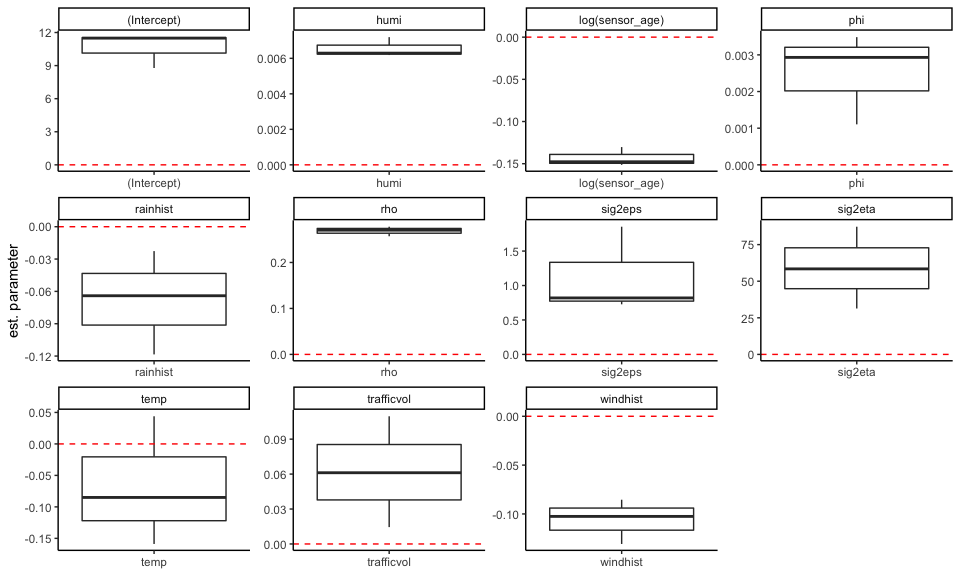

```r
plot(para.1week)
```

# How to choose the knots

There are three methods how to specify the knots (1) Use a matrix of your favorite knots coordinates (2) Specify a regular grid by choosing the column and row count (3) Choose a random knots location based on the density of the position of the sensors. For more details see the master-thesis: Spatio-temporal modelling of air pollution open data (1): I don’t have my favorite locations in Munich in coordinates, so I choose randomly 20 grid points from the dataset muc_airPol_p2_grid

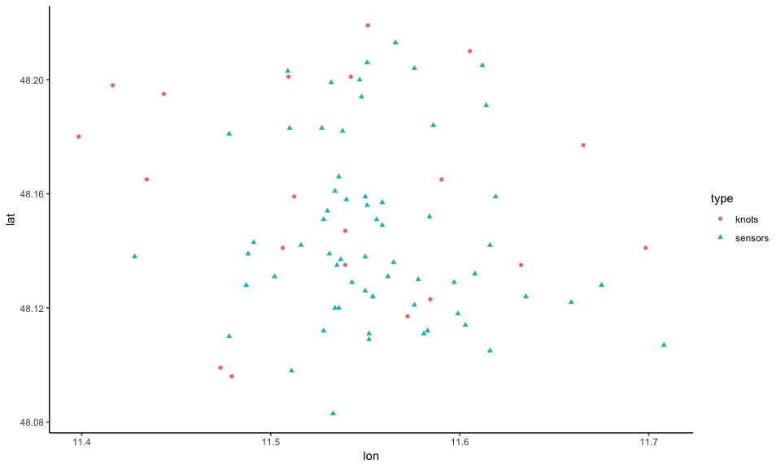

```
#>
#>  Output: GPP approximation models
#> ---------------------------------------------------------------
#>  Sampled: 5000 of 5000, 100.00%.
#>  Batch Acceptance Rate (phi): 51.51%
#>  Checking Parameters:
#>    phi: 2.4268, rho: 0.1631, sig2eps: 0.4080, sig2eta: 1.4695
#>    beta[1]: 4.3491   beta[2]: 0.0100   beta[3]: -0.0495   beta[4]: -0.0565   beta[5]: -0.0904   beta[6]: 0.0568   beta[7]: -0.1574
#> ---------------------------------------------------------------
#> ##
#> # nBurn =  1000 . Iterations =  5000 .
#> # Acceptance rate: (phi) =  51.5 %
#> ##
#> ##
#> # Elapsed time: 3.61 Sec.
#> ##
#>
#> # Model: GPP

pred.gpp.selected <- predict(model.gpp.selected, data, training_set)
#> Warning in if (class(newdata) %in% c("STFDF", "STSDF", "STIDF",
#> "SpatialPointsDataFrame")) {: the condition has length > 1 and only the
#> first element will be used
#> Warning in if (class(newdata) %in% c("ST", "STTDF")) {: the condition has
#> length > 1 and only the first element will be used
#>
#>  Prediction: GPP models
#> -------------------------------------------------
#>   Sampled: 400 of 4000, 10.00%
#> -------------------------------------------------
#> -------------------------------------------------
#>   Sampled: 800 of 4000, 20.00%
#> -------------------------------------------------
#> -------------------------------------------------
#>   Sampled: 1200 of 4000, 30.00%
#> -------------------------------------------------
#> -------------------------------------------------
#>   Sampled: 1600 of 4000, 40.00%
#> -------------------------------------------------
#> -------------------------------------------------
```

[output cut: 9 more lines]

```
#>   Sampled: 3200 of 4000, 80.00%
#> -------------------------------------------------
#> -------------------------------------------------
#>   Sampled: 3600 of 4000, 90.00%
#> -------------------------------------------------
#> -------------------------------------------------
#>   Sampled: 4000 of 4000, 100.00%
#> -------------------------------------------------
#> ##
#> # Predicted samples and summary statistics are given.
#> # nBurn =  1000 . Iterations =  5000 .
#> ##
#> ##
#> # Elapsed time: 1.97 Sec.
#> ##
```

```r
data("muc_airPol_p2_grid")
set.seed(2202)
count <- nrow(unique(muc_airPol_p2_grid[, .(lon, lat)]))
knots <- as.matrix(unique(muc_airPol_p2_grid[, .(lon, lat)])[sample(1:count, 20)])
model.gpp.selected <- fit_sp_model(data = data,
                             formula = formula,
                             model = 'GPP',
                             priors = priors.gpp,
                             cov.fnc = cov.fnc,
                             knots = knots,
                             knots_plot = TRUE,
                             training_set = training_set,
                             scale.transform = scale.transform,
                             spatial.decay = spatial.decay)
```

2. I want a 5 times 4 grid, so I set knots_count = c(5,4)

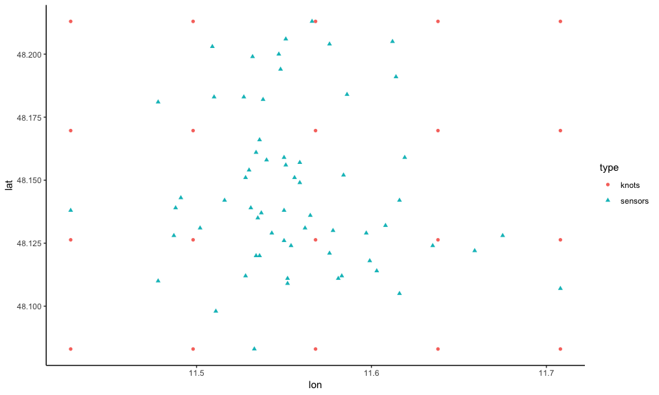

```
#>
#>  Output: GPP approximation models
#> ---------------------------------------------------------------
#>  Sampled: 5000 of 5000, 100.00%.
#>  Batch Acceptance Rate (phi): 13.64%
#>  Checking Parameters:
#>    phi: 0.0001, rho: 0.2752, sig2eps: 0.3890, sig2eta: 143.9345
#>    beta[1]: 22.6072   beta[2]: 0.0057   beta[3]: -0.0570   beta[4]: -0.0443   beta[5]: -0.0937   beta[6]: -0.0040   beta[7]: -0.0919
#> ---------------------------------------------------------------
#> ##
#> # nBurn =  1000 . Iterations =  5000 .
#> # Acceptance rate: (phi) =  13.64 %
#> ##
#> ##
#> # Elapsed time: 3.68 Sec.
#> ##
#>
#> # Model: GPP
pred.gpp.grid <- predict(model.gpp.grid, data, training_set)
#> Warning in if (class(newdata) %in% c("STFDF", "STSDF", "STIDF",
#> "SpatialPointsDataFrame")) {: the condition has length > 1 and only the
#> first element will be used
#> Warning in if (class(newdata) %in% c("ST", "STTDF")) {: the condition has
#> length > 1 and only the first element will be used
#>
#>  Prediction: GPP models
#> -------------------------------------------------
#>   Sampled: 400 of 4000, 10.00%
#> -------------------------------------------------
#> -------------------------------------------------
#>   Sampled: 800 of 4000, 20.00%
#> -------------------------------------------------
#> -------------------------------------------------
#>   Sampled: 1200 of 4000, 30.00%
#> -------------------------------------------------
#> -------------------------------------------------
#>   Sampled: 1600 of 4000, 40.00%
#> -------------------------------------------------
#> -------------------------------------------------
#>   Sampled: 2000 of 4000, 50.00%
```

[output cut: 8 more lines]

```
#>   Sampled: 3200 of 4000, 80.00%
#> -------------------------------------------------
#> -------------------------------------------------
#>   Sampled: 3600 of 4000, 90.00%
#> -------------------------------------------------
#> -------------------------------------------------
#>   Sampled: 4000 of 4000, 100.00%
#> -------------------------------------------------
#> ##
#> # Predicted samples and summary statistics are given.
#> # nBurn =  1000 . Iterations =  5000 .
#> ##
#> ##
#> # Elapsed time: 1.74 Sec.
#> ##
```

```r
model.gpp.grid <- fit_sp_model(data = data,
                          formula = formula,
                          model = 'GPP',
                          priors = priors.gpp,
                          cov.fnc = cov.fnc,
                          knots_count = c(5,4),
                          knots_plot = TRUE,
                          training_set = training_set,
                          scale.transform = scale.transform,
                          spatial.decay = spatial.decay)
```

3. I want to set 20 random knots based on the sensor density

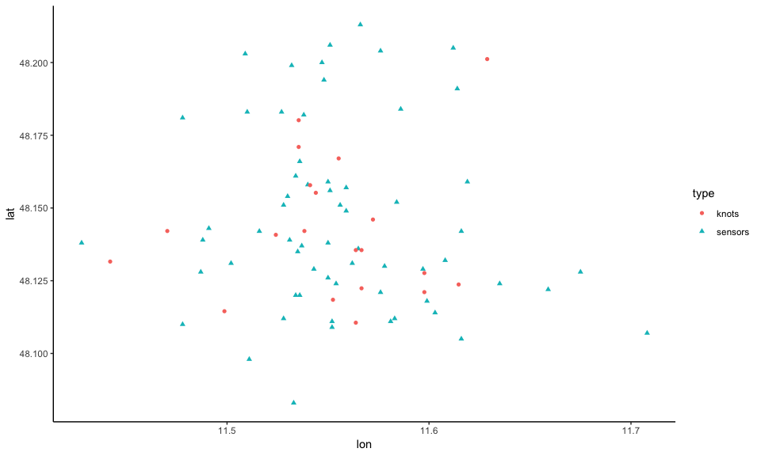

```
#>
#>  Output: GPP approximation models
#> ---------------------------------------------------------------
#>  Sampled: 5000 of 5000, 100.00%.
#>  Batch Acceptance Rate (phi): 42.63%
#>  Checking Parameters:
#>    phi: 2.7827, rho: 0.0770, sig2eps: 0.5862, sig2eta: 0.4693
#>    beta[1]: 3.6742   beta[2]: 0.0071   beta[3]: -0.0621   beta[4]: -0.0517   beta[5]: -0.0914   beta[6]: 0.0771   beta[7]: -0.0849
#> ---------------------------------------------------------------
#> ##
#> # nBurn =  1000 . Iterations =  5000 .
#> # Acceptance rate: (phi) =  42.62 %
#> ##
#> ##
#> # Elapsed time: 3.42 Sec.
#> ##
#>
#> # Model: GPP
pred.gpp.random <- predict(model.gpp.random, data, training_set)
#> Warning in if (class(newdata) %in% c("STFDF", "STSDF", "STIDF",
#> "SpatialPointsDataFrame")) {: the condition has length > 1 and only the
#> first element will be used
#> Warning in if (class(newdata) %in% c("ST", "STTDF")) {: the condition has
#> length > 1 and only the first element will be used
#>
#>  Prediction: GPP models
#> -------------------------------------------------
#>   Sampled: 400 of 4000, 10.00%
#> -------------------------------------------------
#> -------------------------------------------------
#>   Sampled: 800 of 4000, 20.00%
#> -------------------------------------------------
#> -------------------------------------------------
#>   Sampled: 1200 of 4000, 30.00%
#> -------------------------------------------------
#> -------------------------------------------------
#>   Sampled: 1600 of 4000, 40.00%
#> -------------------------------------------------
#> -------------------------------------------------
#>   Sampled: 2000 of 4000, 50.00%
```

[output cut: 8 more lines]

```
#>   Sampled: 3200 of 4000, 80.00%
#> -------------------------------------------------
#> -------------------------------------------------
#>   Sampled: 3600 of 4000, 90.00%
#> -------------------------------------------------
#> -------------------------------------------------
#>   Sampled: 4000 of 4000, 100.00%
#> -------------------------------------------------
#> ##
#> # Predicted samples and summary statistics are given.
#> # nBurn =  1000 . Iterations =  5000 .
#> ##
#> ##
#> # Elapsed time: 1.89 Sec.
#> ##
```

```r
model.gpp.random <- fit_sp_model(data = data,
                          formula = formula,
                          model = 'GPP',
                          priors = priors.gpp,
                          cov.fnc = cov.fnc,
                          knots_count = 20,
                          knots_method = 'random',
                          knots_plot = TRUE,
                          knots_seed = 220292,
                          training_set = training_set,
                          scale.transform = scale.transform,
                          spatial.decay = spatial.decay)
```

Compair the results

```r
evaluate_prediction_table(list('pred.gpp.selected' = pred.gpp.selected,
                               'pred.gpp.grid' = pred.gpp.grid,
                               'pred.gpp.random' = pred.gpp.random))
```

```
#>                model RMSE  MAE  BIAS Coverage   R2
#> 1: pred.gpp.selected 4.17 3.26 -0.11     0.98 0.65
#> 2:     pred.gpp.grid 4.28 3.34 -0.23     0.96 0.62
#> 3:   pred.gpp.random 4.06 3.13 -0.35     0.98 0.68
```